# Regional Voting Preferences in the 2019 Philippine Senatorial Elections

Looks like voting in the Philippines is all about location, location, location! Literacy and religion may not be factors, but hometown pride definitely is.

elections

python

analysis

Published

April 14, 2023

This notebook was created for our Data Mining and Wrangling class in AIM MSDS. In particular, this was done during our 2nd semester of class, as one of the required lab reports. In this notebook, we explored the 2019 elections to see if there are any socio-economic relationships with the results. We analyzed the election results per region and wanted to answer the following questions: (1) Is Demographics Related To Voting Preference?, (2) Is literacy rate related to voting preference?, and (3) Is religion related to voting preference?

[output not shown]

[output not shown]

# Regional Voting Preferences in the 2019 Philippine Senatorial Elections

The Philippines recently concluded its 2019 midterm elections last May 13. Sixty-two (62) candidates from various political parties contested for twelve (12) seats in the Senate of The Philippines. Given the unexpected results, the team was wondering on the following topics:

```
<div class="input_area">
```

```python
from IPython.display import HTML

HTML('''<script>
  function code_toggle() {
    if (code_shown){
      $('div.input').hide('500');
      $('#toggleButton').val('Show Code')
    } else {
      $('div.input').show('500');
      $('#toggleButton').val('Hide Code')
    }
    code_shown = !code_shown
  }

  $( document ).ready(function(){
    code_shown=false;
    $('div.input').hide()
  });
</script>
<form action="javascript:code_toggle()"><input type="submit" id="toggleButton" value="Show Code"></form>''')
```

```
</div>
```

```
<div class="prompt output_prompt">Out[1]:</div>
```

Before anything else, let us first load all important modules for this exercise.

```
<div class="input_area">
```

```python
import os
import io
import re
import time
import glob
import requests
import urllib.request
import numpy as np
import pandas as pd
import geopandas as gpd
import matplotlib.pyplot as plt
from matplotlib.colors import LinearSegmentedColormap
import seaborn as sns
```

```
</div>
```

It is important to identify the datasets we are going to use for this exercise. The two identified datasets the group intends to use are: the 2019 National Data and the 2015-2016 Census data.

With regards to 2019 National data, the team used a web scapper provided Prof. Alis. The web scapper downloaded the election results from the [Commission of Elections’ 2019 National and Local Elections website](https://2019electionresults.comelec.gov.ph/#/dashboard). The results were then stored in a local repository which is then easily accesible for the team. The 2019 elections results are broken down into two main directories: `results` and `contest`. In this exercise, the team will explore both directories to map out a comprehensive summary of the 2019 senatorial and party elections.

Secondly, the 2015-2016 Census data has already been stored in a local repository for easier access. One of the main reasons why the team decided to use the 2015-2016 Census data is because of the lack of availability of recent data. The Philippine Statistics Authority only releases a comprehensive census survey ever six years. However for the purpose of this exercise, the team has agreed that the 2015-2016 census data can act as an appproximate for today’s population.

## A. Methodology

### Step 1: Extract and collect the 2019 Elections (Results) data

The first directory to explore is the 2019 Election `results`. The `results` directory contains all electoral results from a regional level down to the barangay level. For each level, a specific `coc.json` file is stored. This file contains all electoral results data and metadata for both national and local elections. However for the purposes of this analysis, we will only look at the aggregated elections data at the regional level. The files that we are interested are the `coc.json` files associated to each province, as these files contain the metadata and data on the election results.

The main structure of each `coc.json` file contains the following main keys: `vbc`, `rs`, `sts`, `obs`, and `cos`. For the purpose of this exercise, the important key the group needs to extract is the `rs` key as this provides the each candidate’s total votes per area. Under the `rs` key, the following keys can be found: `cc`, `bo`, `v`, `tot`, `per`, and `ser`. Cross referencing these keys with official statements and comelec documentations suggests that important keys are as follows: `cc` pertaining to `contest_type`, `bo` pertaining to the `candidate_id`, and `v` pertaining to `votes_per_province`.

| Parameter | Description |
| --- | --- |
| cc | Contest code |
| bo | Contestant id |
| v | Total votes per contestant |
| tot | Total votes per province |

However, it must be pointed out that the available data only goes as high as provincial data. If we want to process the provincial level, the team will have to aggregate the data up.

The group created utility functions for easier retrieval of the provincial elections datasets. The purpose for the utility functions (and future utility functions) are for initial cleaning and manipulations. This is to ensure each dataset is ready for aggregation.

The `get_province_coc` method unpacks each key and value from the `coc.json` dictionary into a cleaned up dataframe. In addition, the method identifies which region and province the file originated from by examining the filepath that was passed.

The `get_all_province_coc` method is a walker that goes through each of the `results` directory. The walker checks if the filename has an equal value to `coc.json`. If a `coc.json` was located, the `get_province_coc` method is applied with the `filepath` as the parameter. The resulting dataframe is then appended to a master dataframe for further extraction and analysis. For this exercise, the group only had to extract data up to the regional and provincial levels so only three wildcard were use for the `glob` walker.

Special methods (`get_ncr_coc` and `get_all_ncr_coc`) were established to get the cities’ `coc.json`. For the case of the NCR cities, theire associated `coc.json` files were one directory lower.

```
<div class="input_area">
```

```python
def get_province_coc(filepath):
    """
    Loads a single coc file.

    Adds additional columns `region` and `province to the DataFrame,
    depending on filepath.

    Parameters
    ----------
    filepath    : filepath

    Return
    ------
    df          : a dataframe
    """
    output = []
    with open(filepath, 'r') as f:
        dirpath, filepath = os.path.split(filepath)
        region = dirpath.split('/')[-2]
        province = dirpath.split('/')[-1]
        data = json.load(f)
        for each in data['rs']:
            row = [float(element) for element in list(each.values())]
            output.append([data['vbc']] + row + [region] + [province])
    df = pd.DataFrame(output,
                      columns=['vbc', 'cc', 'bo', 'v', 'tot', 'per', 'ser',
                               'region', 'province'])
    return df


def get_all_province_coc(tree):
    """
    Loads all province COC files and saves them to a dataframe

    Checks the filepath if filename is 'coc.json'

    Created a new column to deal with the reclassification of
        "NEGROS ORIENTAL" and "NEGROS OCCIDENTAL" to "NIR"
            to match the PSA 2016 dataset.

    Parameters
    ----------
    filepath    : filepath

    Return
    ------
    df          : a dataframe
    """
    total = pd.DataFrame()
    for file in glob.glob(tree):
        if os.path.basename(file) == 'coc.json':
            df = get_province_coc(file)
            total = total.append(df)
    total.rename(columns={'region': 'region_raw'}, inplace=True)
    total['region'] = total['region_raw'].copy()
    total.loc[(total['province'] == "NEGROS ORIENTAL") |
              (total['province'] == "NEGROS OCCIDENTAL"), 'region'] = 'NIR'
    return total
```

```
</div>
```

```
<div class="input_area">
```

```python
def get_ncr_coc(filepath):
    """
    Loads a single coc file.

    Adds additional columns `region` and `province to the DataFrame,
    depending on filepath.

    Parameters
    ----------
    filepath    : filepath

    Return
    ------
    df          : a dataframe

    """
    output = []
    with open(filepath, 'r') as f:
        dirpath, filepath = os.path.split(filepath)
        region = dirpath.split('/')[-3]
        province = dirpath.split('/')[-2]
        data = json.load(f)
        for each in data['rs']:
            row = [float(element) for element in list(each.values())]
            output.append([data['vbc']] + row + [region] + [province])
    df = pd.DataFrame(output,
                      columns=['vbc', 'cc', 'bo', 'v', 'tot', 'per', 'ser',
                               'region', 'province'])
    return df


def get_all_ncr_coc(tree):
    """
    Loads all province COC files and saves them to a dataframe

    Checks the filepath if filename is 'coc.json'

    Parameters
    ----------
    filepath    : filepath

    Return
    ------
    df          : a dataframe
    """
    total = pd.DataFrame()
    for file in glob.glob(tree):
        if file.split('/')[7] == 'NCR':
            if os.path.basename(file) == 'coc.json':
                df = get_ncr_coc(file)
                total = total.append(df)
    total.rename(columns={'region': 'region_raw'}, inplace=True)
    total['region'] = total['region_raw'].copy()
    return total
```

```
</div>
```

### With these utility functions inplace, the team can now apply these methods for easier access to the 2019 elections data.

We can now compile all of the election results with the following line:

```
<div class="input_area">
```

```python
tree = '/mnt/data/public/elections/nle2019/results/*/*/*'
ncr_tree = '/mnt/data/public/elections/nle2019/results/*/*/*/*'
df_results = get_all_province_coc(tree)
df_results = df_results.append(get_all_ncr_coc(ncr_tree))
df_results.drop_duplicates(inplace=True)
```

```
</div>
```

```
<div class="input_area">
```

```python
df_results.head(5)
```

```
</div>
```

```
<div class="prompt output_prompt">Out[6]:</div>
```

|  | vbc | cc | bo | v | tot | per | ser | region_raw | province | region |
| --- | --- | --- | --- | --- | --- | --- | --- | --- | --- | --- |
| 0 | 89550 | 1.0 | 1.0 | 2004.0 | 1708769.0 | 0.11 | 2800.0 | REGION I | ILOCOS NORTE | REGION I |
| 1 | 89550 | 1.0 | 2.0 | 1607.0 | 1708769.0 | 0.09 | 2800.0 | REGION I | ILOCOS NORTE | REGION I |
| 2 | 89550 | 1.0 | 3.0 | 8772.0 | 1708769.0 | 0.51 | 2800.0 | REGION I | ILOCOS NORTE | REGION I |
| 3 | 89550 | 1.0 | 4.0 | 1767.0 | 1708769.0 | 0.10 | 2800.0 | REGION I | ILOCOS NORTE | REGION I |
| 4 | 89550 | 1.0 | 5.0 | 5068.0 | 1708769.0 | 0.29 | 2800.0 | REGION I | ILOCOS NORTE | REGION I |

### Next, let us examine the obtained dataset with actual election results.

By cross checking the results with [Comelec data](https://www.comelec.gov.ph/?r=2019NLE/ListsOfCandidates/CertifiedListofCandidates), we can identify the senators and party names.

Just to check our data, we can look at an example senator from the dataset. By choosing `cc=1` and `bo=46`, we are actually highlighting Imee Marcos’ senatorial candidacy results.

```
<div class="input_area">
```

```
</div>
```

```
<div class="prompt"></div>
```

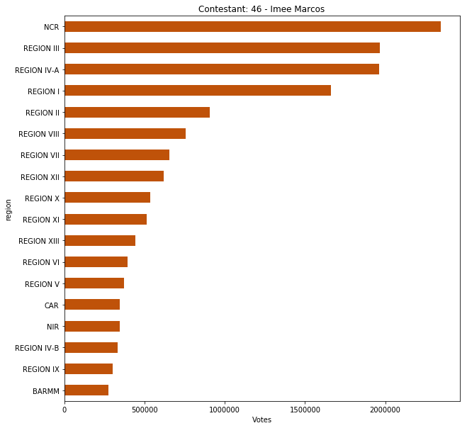

```python
fig, ax = plt.subplots()
ax.set_xlabel('Votes')
df_marcos = df_results.query('cc == 1 & bo == 46').copy()
df_marcos.groupby('region').sum()['v'].sort_values(
    ascending=True).plot.barh(figsize=(10, 10),
                              title='Contestant: 46 - Imee Marcos',
                              color='#BF5209', ax=ax);
```

Additionally, let us check some descriptive statistics for the 2019 Elections dataset. More specifically, let us examine the `v` or `votes` column. The group will be highly dependent on the `votes` data so let us first do some initial statistics and visualizations.

```
<div class="input_area">
```

```python
df_test = df_results.groupby(['region', 'province'])['v'].sum().to_frame()
df_test = df_test.rename(columns={'v': 'votes'})
df_test
```

```
</div>
```

```
<div class="prompt output_prompt">Out[8]:</div>
```

| region | province | votes |
| --- | --- | --- |
| BARMM | BASILAN | 2093067.0 |
|  | LANAO DEL SUR | 4770462.0 |
|  | MAGUINDANAO | 5917983.0 |
|  | SULU | 3529555.0 |
|  | TAWI-TAWI | 1874486.0 |
| CAR | ABRA | 1923481.0 |
|  | APAYAO | 703002.0 |
|  | BENGUET | 2426397.0 |
|  | IFUGAO | 1408688.0 |
|  | KALINGA | 1621414.0 |
|  | MOUNTAIN PROVINCE | 1074249.0 |
| NCR | NATIONAL CAPITAL REGION - FOURTH DISTRICT | 22896771.0 |
|  | NATIONAL CAPITAL REGION - MANILA | 13461229.0 |
|  | NATIONAL CAPITAL REGION - SECOND DISTRICT | 29803007.0 |
|  | NATIONAL CAPITAL REGION - THIRD DISTRICT | 18481014.0 |
|  | TAGUIG - PATEROS | 10018306.0 |
| NIR | NEGROS OCCIDENTAL | 12453486.0 |
|  | NEGROS ORIENTAL | 6900077.0 |
| REGION I | ILOCOS NORTE | 3614806.0 |
|  | ILOCOS SUR | 4882048.0 |
|  | LA UNION | 5764844.0 |
|  | PANGASINAN | 19803192.0 |
| REGION II | BATANES | 118412.0 |
|  | CAGAYAN | 6890994.0 |
|  | ISABELA | 9632919.0 |
|  | NUEVA VIZCAYA | 3200395.0 |
|  | QUIRINO | 1198929.0 |
| REGION III | AURORA | 1493909.0 |
|  | BATAAN | 6433641.0 |
|  | BULACAN | 19567555.0 |
| … | … | … |
| REGION VI | GUIMARAS | 1217864.0 |
|  | ILOILO | 11118379.0 |
| REGION VII | BOHOL | 8977777.0 |
|  | CEBU | 19919139.0 |
|  | SIQUIJOR | 694813.0 |
| REGION VIII | BILIRAN | 1051266.0 |
|  | EASTERN SAMAR | 3370187.0 |
|  | LEYTE | 9366390.0 |
|  | NORTHERN SAMAR | 3733282.0 |
|  | SAMAR (WESTERN SAMAR) | 5954800.0 |
|  | SOUTHERN LEYTE | 2558108.0 |
| REGION X | BUKIDNON | 7415656.0 |
|  | CAMIGUIN | 768370.0 |
|  | LANAO DEL NORTE | 3584638.0 |
|  | MISAMIS OCCIDENTAL | 4391884.0 |
|  | MISAMIS ORIENTAL | 6488743.0 |
| REGION XI | COMPOSTELA VALLEY | 4281424.0 |
|  | DAVAO (DAVAO DEL NORTE) | 7056455.0 |
|  | DAVAO DEL SUR | 4457484.0 |
|  | DAVAO OCCIDENTAL | 1378314.0 |
|  | DAVAO ORIENTAL | 3200605.0 |
| REGION XII | COTABATO (NORTH COT.) | 7659458.0 |
|  | SARANGANI | 2990485.0 |
|  | SOUTH COTABATO | 9090438.0 |
|  | SULTAN KUDARAT | 4037874.0 |
| REGION XIII | AGUSAN DEL NORTE | 4670054.0 |
|  | AGUSAN DEL SUR | 4155305.0 |
|  | DINAGAT ISLANDS | 735236.0 |
|  | SURIGAO DEL NORTE | 3979284.0 |
|  | SURIGAO DEL SUR | 4116338.0 |

86 rows × 1 columns

```
<div class="input_area">
```

```
</div>
```

```
<div class="prompt"></div>
```

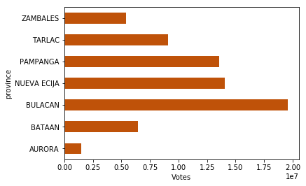

```python
fig, ax = plt.subplots()
ax.set_xlabel('Votes')
df_test.loc['REGION III',"votes"].plot.barh(color='#BF5209', ax=ax);
```

```
<div class="input_area">
```

```
</div>
```

```
<div class="prompt"></div>
```

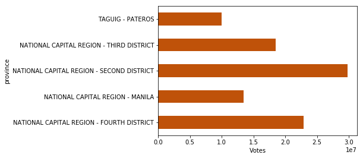

```python
fig, ax = plt.subplots()
ax.set_xlabel('Votes')
df_test.loc['NCR',"votes"].plot.barh(color='#BF5209', ax=ax);
```

```
<div class="input_area">
```

```
</div>
```

```
<div class="prompt"></div>
```

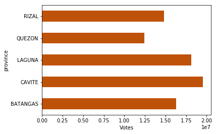

```python
fig, ax = plt.subplots()
ax.set_xlabel('Votes')
df_test.loc['REGION IV-A',"votes"].plot.barh(color='#BF5209', ax=ax);
```

```
<div class="input_area">
```

```
</div>
```

```
<div class="prompt"></div>
```

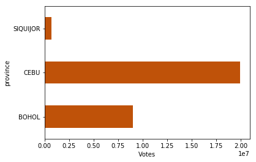

```python
fig, ax = plt.subplots()
ax.set_xlabel('Votes')
df_test.loc['REGION VII',"votes"].plot.barh(color='#BF5209', ax=ax);
```

To match the contestant ID to the contestant name, the `contest` files were also downloaded from the [Commission of Elections’ 2019 National and Local Elections website](https://2019electionresults.comelec.gov.ph/#/dashboard) and stored in the local repository. Similar to the `results` directory, the `contest` directory contained json files for each contest type/position. Upon inspection of a sample file within the directory, the following values were obtained:

The pertinent keys from each json files were:

| Parameter | Description |
| --- | --- |
| cc | Contest code |
| cn | Contest code name - location |
| ccc | Contest code name |
| type | Contest type |
| bos | list of candidate parameters |

Under the `bos` key, we can extract each of the candidates’ parameters. The more useful ones for the group’s study include:

| Parameter | Description |
| --- | --- |
| boc | Contestant ID |
| bon | Contestant Name |
| pn | Party Name |

### Step 2: Extract and collect the 2019 Elections (Contestant) data

The group also created utility functions for easier retrieval of the contestant datasets. This is to ensure each dataset is ready for aggregation.

Similar to the `get_province_coc`, the `get_contestant_attrib` method unpacks each key and value from the `{contest_number}.json` dictionary into a cleaned up dataframe. The method converts the `bos` directory into an additional list, which will also be appended into the resulting dataframe.

There are two (2) major political coalitions fighting for the senate seats:</font>

- **Hugpong ng Pagbabago (HNP)**
- **Otso Diretso**

Similar to the `get_all_province_coc`, the `get_contestants_attrib` method is a walker that goes through each of the `contest` directory. The method will first append all `{contest_numer}.json` files into a singular dataframe. Next, the method creates a new column that identifies who among the senatorial candidates are part of the **Hugpong ng Pagbabago (HNP)** or **Otso Diretso campaign**.

```
<div class="input_area">
```

```python
def get_contestant_attrib(filepath):
    """
    Returns the contestant json file into a dataframe

    Parameters
    ----------
    filepath   : string

    Returns
    ----------
    df         : pd.DataFrame of contestnat attributes

    """

    contestants_values = []
    with open(filepath, 'r') as file:
        data = json.load(file)
        attrib_keys = [key for key in list(data.keys())
                       if isinstance(key, (str, float, int))]
        attrib_values = [value for value in list(data.values())
                         if isinstance(value, (str, float, int))]
        contest_values = [list(contest.values()) for contest in data['bos']]
        df = pd.DataFrame(contest_values,
                          columns=list(data['bos'][0].keys()))
        for k, v in zip(attrib_keys, attrib_values):
            df[k] = v
    return df


def get_contestants_attrib(filepath):
    """
    Returns ALL contestant json files into a dataframe

    Parameters
    ----------
    filepath   : string

    Returns
    ----------
    df         : pd.DataFrame of contestant attributes

    """
    df = pd.DataFrame()
    for each_filepath in glob.glob(filepath):
        df = df.append(get_contestant_attrib(each_filepath))
    senators = df[df.cc == 1].copy()
    senators['bon'] = senators['bon'].str.extract(pat='(.*?) \(')
    party = df[df.cc == 5567].copy()
    df = senators.append(party)
    df.drop_duplicates(inplace=True)
    df.rename(columns={'boc': 'bo'}, inplace=True)
    otso = ['AQUINO, BENIGNO BAM ', 'DIOKNO, CHEL', 'HILBAY, PILO',
            'MACALINTAL, MACAROMY', 'GUTOC, SAMIRA', 'ALEJANO, GARY',
            'ROXAS, MAR', 'TAÑADA,LORENZO ERIN TAPAT']
    hnp = ['ANGARA, EDGARDO SONNY', 'BONG REVILLA, RAMON JR', 'CAYETANO, PIA',
           'DELA ROSA, BATO', 'EJERCITO, ESTRADA JV', 'ESTRADA, JINGGOY',
           'GO, BONG GO', 'MANGUDADATU, DONG', 'MANICAD, JIGGY',
           'MARCOS, IMEE', 'PIMENTEL, KOKO', 'TOLENTINO, FRANCIS',
           'VILLAR, CYNTHIA']
    for o in otso:
        df.loc[df.bon == o, 'coalition'] = "Otso Diretso"
    for h in hnp:
        df.loc[df.bon == h, 'coalition'] = "HNP"
    df['coalition'] = df['coalition'].fillna('None')
    return df
```

```
</div>
```

Let us run the `get_contestants_attrib`. This will be used later in the blog for our further analysis.

```
<div class="input_area">
```

```python
contestant_filepaths = '/mnt/data/public/elections/nle2019/contests/*'
df_contestants = get_contestants_attrib(contestant_filepaths)
df_contestants.head()
```

```
</div>
```

```
<div class="prompt output_prompt">Out[15]:</div>
```

|  | bo | bon | boi | to | pc | pn | pcc | pcy | pcm | pck | cc | cn | ccc | ccn | pre | type | coalition |
| --- | --- | --- | --- | --- | --- | --- | --- | --- | --- | --- | --- | --- | --- | --- | --- | --- | --- |
| 0 | 37 | HILBAY, PILO | 52.png | 37 | 2 | AKSYON DEMOKRATIKO | 1 | 1 | 1 | 1 | 1 | SENATOR PHILIPPINES | 1 | SENATOR | 3 | national | Otso Diretso |
| 1 | 7 | ALUNAN, RAFFY | 53.png | 7 | 3 | BAGUMBAYAN VOLUNTEERS FOR A NEW PHILIPPINES | 1 | 1 | 1 | 1 | 1 | SENATOR PHILIPPINES | 1 | SENATOR | 3 | national | None |
| 2 | 14 | BALDEVARONA, BALDE | 35.png | 14 | 7 | FILIPINO FAMILY PARTY | 1 | 1 | 1 | 1 | 1 | SENATOR PHILIPPINES | 1 | SENATOR | 3 | national | None |
| 3 | 18 | CASIÑO, TOTI | 20.png | 18 | 8 | KATIPUNAN NG DEMOKRATIKONG PILIPINO(KDP) | 1 | 1 | 1 | 1 | 1 | SENATOR PHILIPPINES | 1 | SENATOR | 3 | national | None |
| 4 | 21 | CHONG, GLENN | 61.png | 21 | 8 | KATIPUNAN NG DEMOKRATIKONG PILIPINO(KDP) | 1 | 1 | 1 | 1 | 1 | SENATOR PHILIPPINES | 1 | SENATOR | 3 | national | None |

We now have two dataframes: `df_results` containing the 2019 election results, and `df_contestants` containing the contestant information. These two dataframes can now be merged into a single dataframe. Let us also drop certain columns which we have deemed as unimportant.

```
<div class="input_area">
```

```python
def merge_comelec(results, contestants):
    """
    Merge results dataframe with contestants dataframe

    Parameters
    ----------
    results    : pd.DataFrame
    contestants: pd.DataFrame


    Returns
    ----------
    df         : pd.DataFrame of contestant attributes

    """

    df = pd.merge(results, contestants, on=['bo', 'cc'], how='left')
    df = df.drop(['vbc', 'boi', 'to', 'pc', 'pcc', 'pcy', 'pcm',
                  'pck', 'ccc', 'pre', 'ser', 'cn'], axis=1)
    df.columns = ['position', 'candidate_id', 'votes_per_province',
                  'total_votes', 'votes_in_pct', 'region_raw', 'province',
                  'region', 'candidate_name', 'party_name',
                  'contest_position', 'contest_type', 'coalition']
    return df
```

```
</div>
```

```
<div class="input_area">
```

```python
nle2019 = merge_comelec(df_results, df_contestants)
nle2019.region.unique()
```

```
</div>
```

```
<div class="prompt output_prompt">Out[17]:</div>
```

```
array(['REGION I', 'REGION IV-B', 'BARMM', 'REGION II', 'REGION III',
       'REGION V', 'REGION VI', 'NIR', 'REGION VII', 'REGION VIII',
       'REGION IX', 'REGION X', 'REGION XI', 'REGION XII', 'REGION XIII',
       'REGION IV-A', 'CAR', 'NCR'], dtype=object)
```

### Step 3: Load `Geopandas` for geospatial processing

The Philippines is composed of **seventeen (17) administrative regions**. We can use the `geopandas` module to manage and pre-process geospatial data.

Let us first load up a geopandas graph of the Philippines.

```
<div class="input_area">
```

```
</div>
```

```
<div class="prompt"></div>
```

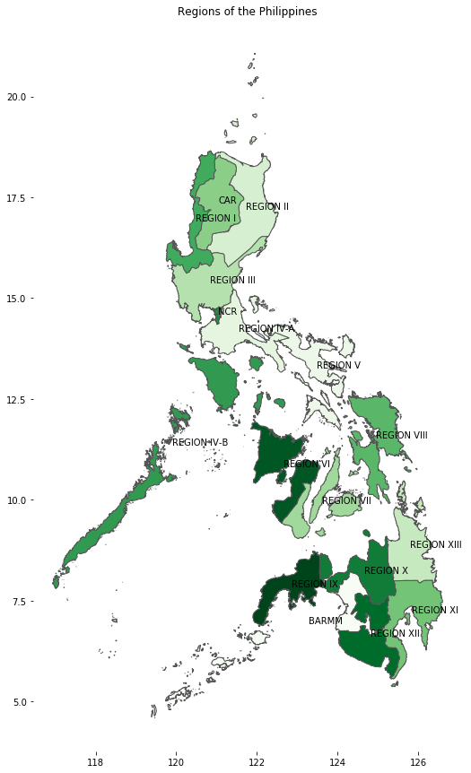

```python
fig, ax = plt.subplots(1, figsize=(10, 15), frameon=True)

ph0 = gpd.GeoDataFrame.from_file("ph_regions.shp")
ph0.plot(ax=ax, cmap='Greens', edgecolor='#555555', k=18)
ax.set_title('Regions of the Philippines')
ax.spines['top'].set_visible(False)
ax.spines['right'].set_visible(False)
ax.spines['bottom'].set_visible(False)
ax.spines['left'].set_visible(False)

for ind, row in ph0.iterrows():
    ax.text(row["geometry"].centroid.x, row["geometry"].centroid.y,
            row["region"])
```

## B. National Senatorial Results

### Let us look at the senatorial candidates. Let us total up the votes by candidate and see the top 12 winners.

```
<div class="input_area">
```

```python
df_senators = nle2019[nle2019['contest_position'] == 'SENATOR']
df_senator = df_senators.groupby(['candidate_name']).agg(
    {'votes_per_province': sum}).reset_index()
df_senator.sort_values('votes_per_province', ascending=False, inplace=True)
df_senator.columns = ['Candidate', 'Votes']
df_senator.head(12)
```

```
</div>
```

```
<div class="prompt output_prompt">Out[19]:</div>
```

|  | Candidate | Votes |
| --- | --- | --- |
| 61 | VILLAR, CYNTHIA | 23653546.0 |
| 54 | POE, GRACE | 20877585.0 |
| 33 | GO, BONG GO | 18979132.0 |
| 18 | CAYETANO, PIA | 18287782.0 |
| 23 | DELA ROSA, BATO | 17396249.0 |
| 7 | ANGARA, EDGARDO SONNY | 16826634.0 |
| 39 | LAPID, LITO | 16181906.0 |
| 45 | MARCOS, IMEE | 14735294.0 |
| 59 | TOLENTINO, FRANCIS | 14264142.0 |
| 15 | BONG REVILLA, RAMON JR | 13899831.0 |
| 14 | BINAY, NANCY | 13864931.0 |
| 53 | PIMENTEL, KOKO | 13529531.0 |

```
<div class="input_area">
```

```
</div>
```

```
<div class="prompt"></div>
```

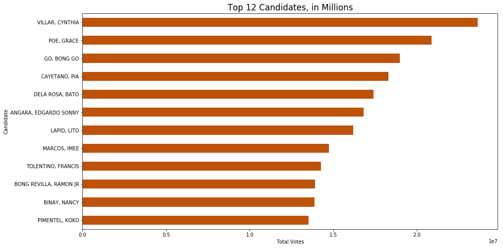

```python
fig, ax = plt.subplots(figsize=(15,8))
plt.rcParams.update({'font.size': 14})
df_senator.set_index('Candidate').head(12).sort_values(
    by='Votes', ascending=True).plot.barh(ax=ax,
    title='Top 12 Candidates, in Millions', color='#BF5209', legend=False);
ax.set_xlabel('Total Votes');
```

## C. Top Senator Per Region

We want to find out won across all the regions. If there is any bias for cetain candidates. Based on our findings, we can see that candidate Cynthia Villar won majority of the regions.

It is interesting to note that the top ranking senator for Ilocos Region (Region I) and the Cordillera Administrative Region (CAR) is **Imee Marcos**, which hails from that region. This confirms that there is a “Solid North”, and that support for the Marcoses still exists in that area.

These show that Philippine politics is **very regional in nature**. Voters will naturally support their hometown candidate, regardless of the issues surrounding that candidate.

```
<div class="input_area">
```

```python
df_senator_region = df_senators.groupby(
    ['region', 'candidate_name']).agg({'votes_per_province': sum})
df_senator_region['rank'] = df_senator_region.groupby(
    'region')['votes_per_province'].rank('dense', ascending=False)
df_senator_region = df_senator_region[df_senator_region['rank'] == 1].reset_index()
df_senator_region.columns = ['Region', 'Candidate Name', 'Votes', 'Rank']
df_senator_region
```

```
</div>
```

```
<div class="prompt output_prompt">Out[21]:</div>
```

|  | Region | Candidate Name | Votes | Rank |
| --- | --- | --- | --- | --- |
| 0 | BARMM | GO, BONG GO | 768037.0 | 1.0 |
| 1 | CAR | MARCOS, IMEE | 348303.0 | 1.0 |
| 2 | NCR | VILLAR, CYNTHIA | 3345089.0 | 1.0 |
| 3 | NIR | VILLAR, CYNTHIA | 856992.0 | 1.0 |
| 4 | REGION I | MARCOS, IMEE | 1661318.0 | 1.0 |
| 5 | REGION II | VILLAR, CYNTHIA | 915393.0 | 1.0 |
| 6 | REGION III | VILLAR, CYNTHIA | 3056167.0 | 1.0 |
| 7 | REGION IV-A | VILLAR, CYNTHIA | 3660112.0 | 1.0 |
| 8 | REGION IV-B | VILLAR, CYNTHIA | 688494.0 | 1.0 |
| 9 | REGION IX | GO, BONG GO | 663927.0 | 1.0 |
| 10 | REGION V | POE, GRACE | 1417114.0 | 1.0 |
| 11 | REGION VI | VILLAR, CYNTHIA | 1064681.0 | 1.0 |
| 12 | REGION VII | VILLAR, CYNTHIA | 1307605.0 | 1.0 |
| 13 | REGION VIII | VILLAR, CYNTHIA | 1132757.0 | 1.0 |
| 14 | REGION X | GO, BONG GO | 949392.0 | 1.0 |
| 15 | REGION XI | GO, BONG GO | 1002771.0 | 1.0 |
| 16 | REGION XII | VILLAR, CYNTHIA | 983354.0 | 1.0 |
| 17 | REGION XIII | GO, BONG GO | 777931.0 | 1.0 |

```
<div class="input_area">
```

```python
(df_senator_region[df_senator_region['Rank'] == 1].reset_index().groupby(
    'Candidate Name')['Rank'].sum().to_frame().sort_values(by='Rank')
 .reset_index())
```

```
</div>
```

```
<div class="prompt output_prompt">Out[22]:</div>
```

|  | Candidate Name | Rank |
| --- | --- | --- |
| 0 | POE, GRACE | 1.0 |
| 1 | MARCOS, IMEE | 2.0 |
| 2 | GO, BONG GO | 5.0 |
| 3 | VILLAR, CYNTHIA | 10.0 |

```
<div class="input_area">
```

```
</div>
```

```
<div class="prompt"></div>
```

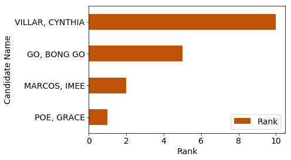

```python
fig, ax = plt.subplots()
(df_senator_region[df_senator_region['Rank'] == 1].reset_index().groupby(
    'Candidate Name')['Rank'].sum().to_frame().sort_values(by='Rank').plot
 .barh(color='#BF5209', ax=ax));
ax.set_xlabel('Rank');
```

## D. Dominant Party per Region

There are three main political parties vying for the senatorial seats:

1. **LIBERAL PARTY**
2. **NACIONALISTA PARTY**
3. **PARTIDO DEMOKRATIKO PILIPINO LAKAS NG BAYAN (PDP-LABAN)**

We looked at the dominant or majority political party per administrative region, and identify if any regions have any affiliations to a certain party.

```
<div class="input_area">
```

```python
df_party = df_senators.groupby(['region_raw', 'party_name']).agg({
    'votes_per_province': sum})
df_party['rank'] = df_party.groupby(
    'region_raw')['votes_per_province'].rank('dense', ascending=False)
df_party.reset_index(inplace=True)
df_leading_party = df_party[df_party['rank'] == 1].copy()
df_leading_party.columns = ['Region', 'Party', 'Votes', 'Rank']
df_leading_party.sort_values(['Region', 'Rank'], inplace=True)
df_leading_party
```

```
</div>
```

```
<div class="prompt output_prompt">Out[24]:</div>
```

|  | Region | Party | Votes | Rank |
| --- | --- | --- | --- | --- |
| 13 | BARMM | PARTIDO DEMOKRATIKO PILIPINO LAKAS NG BAYAN | 2596572.0 | 1.0 |
| 32 | CAR | PARTIDO DEMOKRATIKO PILIPINO LAKAS NG BAYAN | 1028536.0 | 1.0 |
| 51 | NCR | PARTIDO DEMOKRATIKO PILIPINO LAKAS NG BAYAN | 10400476.0 | 1.0 |
| 68 | REGION I | NACIONALISTA PARTY | 4361859.0 | 1.0 |
| 87 | REGION II | NACIONALISTA PARTY | 2474544.0 | 1.0 |
| 108 | REGION III | PARTIDO DEMOKRATIKO PILIPINO LAKAS NG BAYAN | 7804389.0 | 1.0 |
| 127 | REGION IV-A | PARTIDO DEMOKRATIKO PILIPINO LAKAS NG BAYAN | 9542856.0 | 1.0 |
| 146 | REGION IV-B | PARTIDO DEMOKRATIKO PILIPINO LAKAS NG BAYAN | 1733733.0 | 1.0 |
| 165 | REGION IX | PARTIDO DEMOKRATIKO PILIPINO LAKAS NG BAYAN | 2571518.0 | 1.0 |
| 180 | REGION V | LIBERAL PARTY | 4885924.0 | 1.0 |
| 199 | REGION VI | LIBERAL PARTY | 4335427.0 | 1.0 |
| 222 | REGION VII | PARTIDO DEMOKRATIKO PILIPINO LAKAS NG BAYAN | 5480074.0 | 1.0 |
| 241 | REGION VIII | PARTIDO DEMOKRATIKO PILIPINO LAKAS NG BAYAN | 3442654.0 | 1.0 |
| 260 | REGION X | PARTIDO DEMOKRATIKO PILIPINO LAKAS NG BAYAN | 3697535.0 | 1.0 |
| 279 | REGION XI | PARTIDO DEMOKRATIKO PILIPINO LAKAS NG BAYAN | 3654361.0 | 1.0 |
| 298 | REGION XII | PARTIDO DEMOKRATIKO PILIPINO LAKAS NG BAYAN | 3861166.0 | 1.0 |
| 317 | REGION XIII | PARTIDO DEMOKRATIKO PILIPINO LAKAS NG BAYAN | 2858376.0 | 1.0 |

We can clearly see a voting bias of each region.

Majority of Region 1 and Region 2 has a voting preference towards the **NACIONALISTA PARTY**. This can be attributed to the fact that Imee Marcos, who hails from Ilocos Norte, is a Nacionalista.

Majority of Region 5 and Region 6 has a voting preference towards the **LIBERAL PARTY**. This is also expected since Leni Robredo, incumbent Vice President who is from the Liberal Party, is a Bicolano.

The remainder of the Philippines has a voting preference towards the **PDP-LABAN**.

```
<div class="input_area">
```

```
</div>
```

```
<div class="prompt"></div>
```

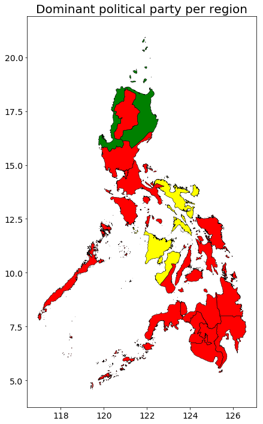

```python
merged = ph0.merge(df_leading_party, left_on='region', right_on='Region')
colors = 18
color_map = {'PARTIDO DEMOKRATIKO PILIPINO LAKAS NG BAYAN': 'red',
             'LIBERAL PARTY': 'yellow',
             'NACIONALISTA PARTY': 'green'}

fig, ax = plt.subplots(1, 1, figsize = (10,12));
ax.set_title('Dominant political party per region', fontsize=20);

for party in list(merged['Party'].unique()):
    color_map[party]
    merged[merged['Party'] == party].plot(ax=ax, color = color_map[party],
                                          categorical = True,
                                          figsize=(10,12), legend=True)

merged.geometry.boundary.plot(color=None,edgecolor='k',linewidth = .5,ax=ax);
plt.rcParams.update({'font.size': 18})
```

## E. Dominant Coalition Per Region

```
<div class="input_area">
```

```
</div>
```

```
<div class="prompt output_prompt">Out[26]:</div>
```

```
<div class="prompt"></div>
```

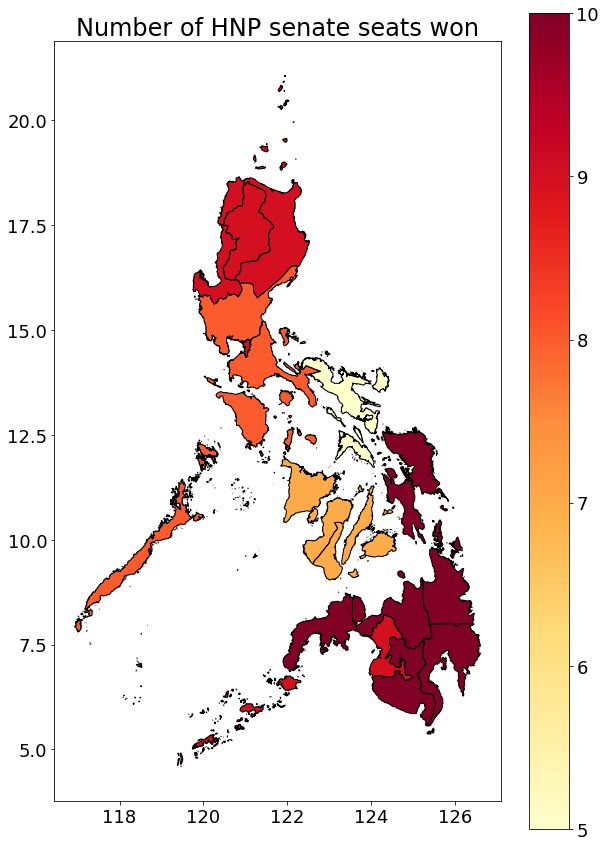

```python
def get_coalition_seats():
    """
    Returns a dataframe of the number of seats won per coalition per region

    Returns
    -------
    coalition : pd.DataFrame

    """
    coalition_seats = nle2019.query('position == 1')

    coalition_seats = coalition_seats.groupby(
        ['region', 'candidate_name', 'coalition'],
        as_index=False).agg({'votes_per_province': sum})
    coalition_seats = coalition_seats.sort_values(
        by=['region', 'votes_per_province'], ascending=[1, 0])
    coalition_seats.set_index('region', inplace=True)

    coalition_seats['rank'] = list(range(1, len(
        coalition_seats.candidate_name.unique())+1))\
        * len(coalition_seats.index.unique())
    coalition_seats['is_top_12'] = 1*(coalition_seats['rank'] <= 12)
    coalition_seats = coalition_seats.reset_index()
    coalition_seats = pd.pivot_table(
        coalition_seats, index='region', columns='coalition',
        values='is_top_12', aggfunc=np.sum)
    coalition_seats['coalition_seats_total'] = coalition_seats.sum(axis=1)

    for coalition in coalition_seats.columns[:-1]:
        coalition_seats['party_seats_pct_' + coalition] = \
            coalition_seats[coalition] / \
            coalition_seats['coalition_seats_total']
        coalition_seats.rename(
            columns={coalition: 'coalition_seats_count_' + coalition},
            inplace=True)

    coalition_seats = coalition_seats.round(5)
    coalition_seats = coalition_seats.reset_index()
    return coalition_seats


coalition = get_coalition_seats()
merged = ph0.merge(coalition[[
                   'region', 'coalition_seats_count_HNP']], left_on='region',
                   right_on='region')

fig, ax = plt.subplots(1, 1, figsize=(10, 15))
merged.plot('coalition_seats_count_HNP', ax=ax, cmap='YlOrRd', legend=True)
ax.set_title('Number of HNP senate seats won', fontsize=24)
merged.geometry.boundary.plot(color=None, edgecolor='k', linewidth=1, ax=ax)
```

## F. Is Demographics Related To Voting Preference?

Is the voting preference of a region related to its demographics such as literacy rate and religious affiliation? To answer this, we obtained the `2015 Census Data`. The directory is a collection of excel files, where each excel file corresponds to a certain region and province. If we explore each file, we can see that each sheet corresponds to a different demographic feature table. For this analysis, we are intrested at sheets `T8` and `T11`.

The `get_census_religion` loads the imporant columns and rows from sheet `T8`. It also adds an additional column based on the region. Similarly, the `get_census_education` loads the imporant columns and rows from sheet `T11`. It also aggregates each individual years experience column into a singular cumulative column.

Finally, the `read_census_files` aggregates the 2016 regional data into singular dataframe by using `get_census_religion` and `get_census_education` functions. To extract only the regional files, the `read_census_files` uses regex to get filenames with only underscores in the beginning (this is an indicator of regional data).

```
<div class="input_area">
```

```python
def get_census_religion(path):
    """
    Returns a consolidated DataFrame of census data by religion

    Parameters
    ----------
    path      : string, filepath to census directory


    Returns
    ----------
    df        : pd.DataFrame

    """
    filename = os.path.basename(path)
    df = pd.read_excel(path, sheet_name='T8', header=None,
                       usecols=[0, 1, 2, 3],
                       skiprows=6, skip_blank_lines=True,
                       skipfooter=3,
                       names=['religion', 'total', 'm', 'f'])
    df.sort_values('total', ascending=False, inplace=True)
    df['region'] = re.search(r'\_(.*?)\_', os.path.basename(path)).group(1)
    cols = ['region', 'religion', 'm', 'f', 'total']
    df = df[cols]
    return df


def get_census_education(path):
    """
    Returns a consolidated DataFrame of census data by education

    Parameters
    ----------
    path      : string, filepath to census directory


    Returns
    ----------
    df        : pd.DataFrame

    """
    filename = os.path.basename(path)
    df = pd.read_excel(path, sheet_name='T11',
                       usecols=[0, 15, 16, 17, 18, 19, 20],
                       skiprows=3,
                       skip_blank_lines=True, nrows=20,
                       names=['education', '18', '19',
                              '20_24', '25_29', '30_34', '35_above'])
    df.dropna(how='any', inplace=True)
    df.reset_index(inplace=True, drop=True)
    df.drop(df.index[[0, 5, 6, 7, 9, 10, 12, 13]], inplace=True)
    df['total'] = (df['18'] + df['19'] + df['20_24'] + df['25_29'] +
                   df['30_34'] + df['35_above'])
    df['region'] = re.search(r'\_(.*?)\_', os.path.basename(path)).group(1)
    cols = ['region', 'education', '18', '19', '20_24', '25_29', '30_34',
            '35_above', 'total']
    df = df[cols]
    return df


def read_census_files(path):
    '''
    Reads all census regional files

    Parameter
    ---------
    path      : string, filepath to census directory

    Returns
    -------
    Dictionary of dataframes
    '''
    total = {'religion': pd.DataFrame(),
             'education': pd.DataFrame()}

    for filepath in glob.glob(path + ".xls", recursive=True):
        if re.match('_(?!PHILIPPINES)', os.path.basename(filepath)):
            total['religion'] = (total['religion']
                                 .append(get_census_religion(filepath)))
            total['education'] = (total['education']
                                  .append(get_census_education(filepath)))
    total['religion'].reset_index(inplace=True, drop=True)
    total['education'].reset_index(inplace=True, drop=True)

    for df in total.values():
        df.loc[(df['region'] == "ARMM"), 'region'] = 'BARMM'
        df.loc[(df['region'] == "MIMAROPA"), 'region'] = 'REGION IV-B'
        df.loc[(df['region'] == "CARAGA"), 'region'] = 'REGION XIII'
    return total
```

```
</div>
```

```
<div class="input_area">
```

```python
census_path = '/mnt/data/public/census/*'
census_dict = read_census_files(census_path)
```

```
</div>
```

## G. Is literacy rate related to voting preference?

We looked at the number of seats obtained by each coalition per region, then correlated it to literacy rate. Education information was obtained from the 2015 Census data.

We looked at the literacy rate $\frac{n_{educated}}{n_{total}}$ of each administrative region:

```
<div class="input_area">
```

```python
def get_education_percent():
    '''
    Gets percentage of educational level per region
    '''
    education = census_dict['education'].groupby(
        ['region', 'education'], as_index=False).sum()
    education = pd.pivot_table(
        education, index='region', columns='education', values='total')
    education.columns = ['education_pct_' + educ for educ in education.columns]
    education['education_total'] = education.sum(axis=1)
    for educ in education.columns[:-1]:
        education[educ] /= education['education_total']
    education.drop('education_total', axis=1, inplace=True)
    education = education.round(5)

    return education


def get_agg_education_percent():
    '''
    Gets aggregated percentage of educational level per region
    '''
    df_educ = get_education_percent()
    df_educ = df_educ.reset_index()
    df_educ['educated'] = (1 - df_educ['education_pct_No Grade Completed']
                           - df_educ['education_pct_Not Stated'])
    df_educ['not_educated'] = df_educ['education_pct_No Grade Completed']
    df_educ['unknown'] = df_educ['education_pct_Not Stated']
    df_educ.drop(columns=['education_pct_Academic Degree Holder',
                          'education_pct_College Undergraduate',
                          'education_pct_Elementary',
                          'education_pct_High School',
                          'education_pct_No Grade Completed',
                          'education_pct_Not Stated',
                          'education_pct_Post Baccalaureate',
                          'education_pct_Post-Secondary',
                          'education_pct_Pre-School',
                          'education_pct_Special Education'], inplace=True)
    df_educ.set_index('region', inplace=True)
    df_educ.reset_index(inplace=True)
    return df_educ


df_educ = get_agg_education_percent()
df_educ
```

```
</div>
```

```
<div class="prompt output_prompt">Out[29]:</div>
```

|  | region | educated | not_educated | unknown |
| --- | --- | --- | --- | --- |
| 0 | BARMM | 0.85355 | 0.14105 | 0.00540 |
| 1 | CAR | 0.97376 | 0.02622 | 0.00002 |
| 2 | NCR | 0.99234 | 0.00221 | 0.00545 |
| 3 | NIR | 0.98085 | 0.01882 | 0.00033 |
| 4 | REGION I | 0.99321 | 0.00679 | 0.00000 |
| 5 | REGION II | 0.98610 | 0.01389 | 0.00001 |
| 6 | REGION III | 0.99355 | 0.00615 | 0.00030 |
| 7 | REGION IV-A | 0.99473 | 0.00519 | 0.00008 |
| 8 | REGION IV-B | 0.96573 | 0.03417 | 0.00010 |
| 9 | REGION IX | 0.96456 | 0.03486 | 0.00058 |
| 10 | REGION V | 0.99126 | 0.00851 | 0.00023 |
| 11 | REGION VI | 0.98721 | 0.01257 | 0.00022 |
| 12 | REGION VII | 0.98753 | 0.01209 | 0.00038 |
| 13 | REGION VIII | 0.97679 | 0.02297 | 0.00024 |
| 14 | REGION X | 0.98095 | 0.01856 | 0.00049 |
| 15 | REGION XI | 0.97818 | 0.02050 | 0.00132 |
| 16 | REGION XII | 0.94792 | 0.05034 | 0.00174 |
| 17 | REGION XIII | 0.98487 | 0.01503 | 0.00010 |

We then checked if the number of seats obtained by each coalition is correlated to the literacy rate of that region. First, we obtained the number of seats obtained by each coalition per region:

```
<div class="input_area">
```

```python
def get_coalition_rank():
    """
    Get number of seats obtained by each coalition
    """
    coalition_seats = nle2019.query('position == 1')
    coalition_seats = coalition_seats.groupby(
        ['region', 'candidate_name', 'coalition'], as_index=False).agg({'votes_per_province': sum})
    coalition_seats = coalition_seats.sort_values(
        by=['region', 'votes_per_province'], ascending=[1, 0])
    coalition_seats.set_index('region', inplace=True)

    coalition_seats['rank'] = list(range(1, len(
        coalition_seats.candidate_name.unique())+1)) * len(coalition_seats.index.unique())
    coalition_seats['is_top_12'] = 1*(coalition_seats['rank'] <= 12)
    coalition_seats.reset_index(inplace=True)

    coalition_seats = pd.pivot_table(
        coalition_seats, index='region', columns='coalition', values='is_top_12', aggfunc=np.sum)
    return coalition_seats
```

```
</div>
```

We then merge this with the education dataframe, then get the correlation:

```
<div class="input_area">
```

```
</div>
```

```
<div class="prompt"></div>
```

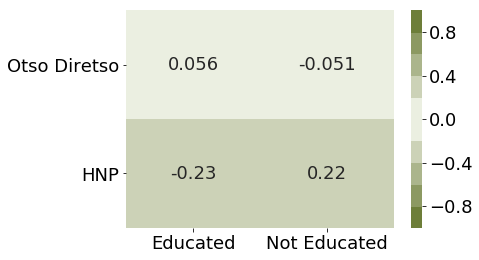

```python
df_coal_educ = get_agg_education_percent().set_index('region').join(get_coalition_rank())
df_coal_educ['Educated'] = df_coal_educ['educated']
df_coal_educ['Not Educated'] = df_coal_educ['not_educated']
corr = df_coal_educ.corr().loc[['Otso Diretso', 'HNP'],['Educated', 'Not Educated']]
colormap = sns.diverging_palette(100, 100, n = 10)
sns.heatmap(corr, cmap=colormap, annot=True, vmin = -1, vmax = 1);
```

The Census and election data show that the voting preference of a region has **no correlation** with its literacy rate. We now look at religion to see if it has a correlation with the voting preference.

## H. Is religion related to voting preference?

We also looked into the religious affiliation per region, and checked if it is correlatd with voting preference.

First, we obtained the distribution of religions per region from the Census data:

```
<div class="input_area">
```

```python
def get_religion_percent():
    """
    Get percentages of religion per region
    """
    religion = census_dict['religion'].groupby(
        ['region', 'religion'], as_index=False).sum()
    religion = pd.pivot_table(
        religion, index='region', columns='religion', values='total')
    religion.columns = ['religion_pct_' + rel for rel in religion.columns]
    religion['religion_total'] = religion.sum(axis=1)
    for rel in religion.columns[:-1]:
        religion[rel] /= religion['religion_total']
    religion.drop('religion_total', axis=1, inplace=True)
    religion = religion.round(5)
    return religion


df_rel = get_religion_percent()
```

```
</div>
```

We then merged the religion census data with the coalition ranking data to check if religion has correlation with the number of seats obtained by each coalition:

```
<div class="input_area">
```

```python
df_coal_rel = get_religion_percent().join(get_coalition_rank())
df_coal_rel.head()
```

```
</div>
```

```
<div class="prompt output_prompt">Out[33]:</div>
```

| region | religion_pct_Aglipay | religion_pct_Association of Baptist Churches in Luzon, Visayas, and Mindanao | religion_pct_Association of Fundamental Baptist Churches in the Philippines | religion_pct_Bible Baptist Church | religion_pct_Bread of Life Ministries | religion_pct_Buddhist | religion_pct_Cathedral of Praise, Incorporated | religion_pct_Church of Christ | religion_pct_Church of Jesus Christ of the Latter Day Saints | religion_pct_Convention of the Philippine Baptist Church | … | religion_pct_Tribal Religions | religion_pct_UNIDA Evangelical Church | religion_pct_Union Espiritista Cristiana de Filipinas, Incorporated | religion_pct_United Church of Christ in the Philippines | religion_pct_United Pentecostal Church (Philippines), Incorporated | religion_pct_Victory Chapel Christian Fellowship | religion_pct_Way of Salvation Church, Incorporated | HNP | None | Otso Diretso |
| --- | --- | --- | --- | --- | --- | --- | --- | --- | --- | --- | --- | --- | --- | --- | --- | --- | --- | --- | --- | --- | --- |
| BARMM | 0.00030 | 0.00001 | 0.00010 | 0.00077 | 0.00000 | 0.00000 | 0.00000 | 0.00008 | 0.00001 | 0.00000 | … | 0.00425 | 0.00000 | 0.00067 | 0.00029 | 0.00021 | 0.00001 | 0.00000 | 9 | 2 | 1 |
| CAR | 0.00340 | 0.00006 | 0.00487 | 0.01283 | 0.00004 | 0.00011 | 0.00002 | 0.00619 | 0.00129 | 0.00001 | … | 0.00186 | 0.00001 | 0.01327 | 0.02350 | 0.01824 | 0.00016 | 0.00011 | 9 | 3 | 0 |
| NCR | 0.00137 | 0.00003 | 0.00005 | 0.00434 | 0.00022 | 0.00113 | 0.00013 | 0.00188 | 0.00121 | 0.00002 | … | 0.00018 | 0.00002 | 0.00001 | 0.00024 | 0.00045 | 0.00532 | 0.00003 | 9 | 3 | 0 |
| NIR | 0.02162 | 0.00006 | 0.00728 | 0.01026 | 0.00007 | 0.00007 | 0.00002 | 0.00267 | 0.00434 | 0.00117 | … | 0.00098 | 0.00000 | 0.00002 | 0.01507 | 0.00196 | 0.00100 | 0.00001 | 7 | 3 | 2 |
| REGION I | 0.00694 | 0.00004 | 0.00010 | 0.00425 | 0.00009 | 0.00009 | 0.00004 | 0.00370 | 0.00388 | 0.00005 | … | 0.00029 | 0.00001 | 0.00259 | 0.00551 | 0.00492 | 0.00032 | 0.00108 | 9 | 3 | 0 |

5 rows × 56 columns

```
<div class="input_area">
```

```
</div>
```

```
<div class="prompt"></div>
```

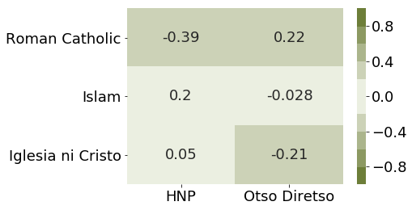

```python
df_coal_rel['Roman Catholic'] = df_coal_rel['religion_pct_Roman Catholic, including Catholic Charismatic']
df_coal_rel['Islam'] = df_coal_rel['religion_pct_Islam']
df_coal_rel['Iglesia ni Cristo'] = df_coal_rel['religion_pct_Iglesia ni Cristo']
corr = df_coal_rel.corr().loc[
    ['Roman Catholic','Islam','Iglesia ni Cristo'],['HNP','Otso Diretso']]
colormap = sns.diverging_palette(100, 100, n = 10)
sns.heatmap(corr, cmap=colormap, annot=True, vmin = -1, vmax = 1);
```

## I. Conclusion

Upon checking both the Comelec 2019 Election Results and the 2015 Philippine Census data, we found out that voting preference is characterized by high regionality. Candidates have a homecourt advantage, and voters tend to vote candidates or parties affiliated with their home region.